# Capitulo 3

Pedro Pablo Villegas

19/9/2019

# VON NEUMANN

- Semilla con 5 dígitos
- Elevar al cuadrado con 10 dígitos (poner ceros iniciales si se necesita)
- Seleccionar los 5 números centrales
- Comenzar nuevamente

```r
vonNeumann <- function(n, semilla) {
  resultados <- numeric(length = n)
  resultados[1] <- semilla
  i <- 2
    while (i <= n) {
      resultados[i] <-
        as.numeric(substr(
          resultados[i - 1]^2,
          nchar(resultados[i - 1]^2) - 7,
          nchar(resultados[i - 1]^2) - 3))
      i <- i + 1
    }
  return(resultados)
}

res <- vonNeumann(n = 1000, semilla = 99999)

plot(x = res[1:length(res)-1], y = res[-1], type = "p")
barplot(res[1:50])
ks.test(res[1:50], "punif")$p.value
pacf(res[1:50])
```

[output not shown]

# GENERADOR LINEAL CONGRUENCIAL

Es un algoritmo para generar números cuasialeatorios

$$x_{i} = ax_{i-1} + c \quad Mod \quad M, \quad para \quad i \geq1$$

donde:

- $a$ es el multiplicador
- $c$ es el incremento
- $M$ es el módulo
- $x_{0}$ es la semilla con $x_{0} < M$

Para obtener la secuencia de números pseudo aleatorios, usamos:

$$y_{i} = \frac{x_i}{M}$$

El algorito empleado es de la forma:

```r
lcg <- function(x0, a, c, M, n){
    x <- numeric(n)
    y <- numeric(n)
    x[1] <- (a*x0 + c) %% M
    y[1] <- x[1]/M
    i <- 2
    while (i <= n) {
        x[i] <- (a*x[i - 1] + c) %% M
        y[i] <- x[i]/M
        i <- i + 1
    }
    return(list(x = x, y = y))
}
```

El período de la función `lcg()` es a lo máximo **M** y para algunas elecciones de los factores, mucho menos que eso.

# PERFORMANCE DEL GENERADOR DE NÚMEROS ALEATORIOS

Para evaluar el rendimiento del generador de números aleatorios, generalmente se chequea:

- Diagrama de dispersión de $x_{n+1}$ vs. $x_{n}$
- Prueba de Kolmogorov-Smirnov para U(0, 1) vía `ks.test`
- Explorando la función de autocorrelación parcial *PACF* con `pacf`

## Generador Lineal Congruencial `lcg()`

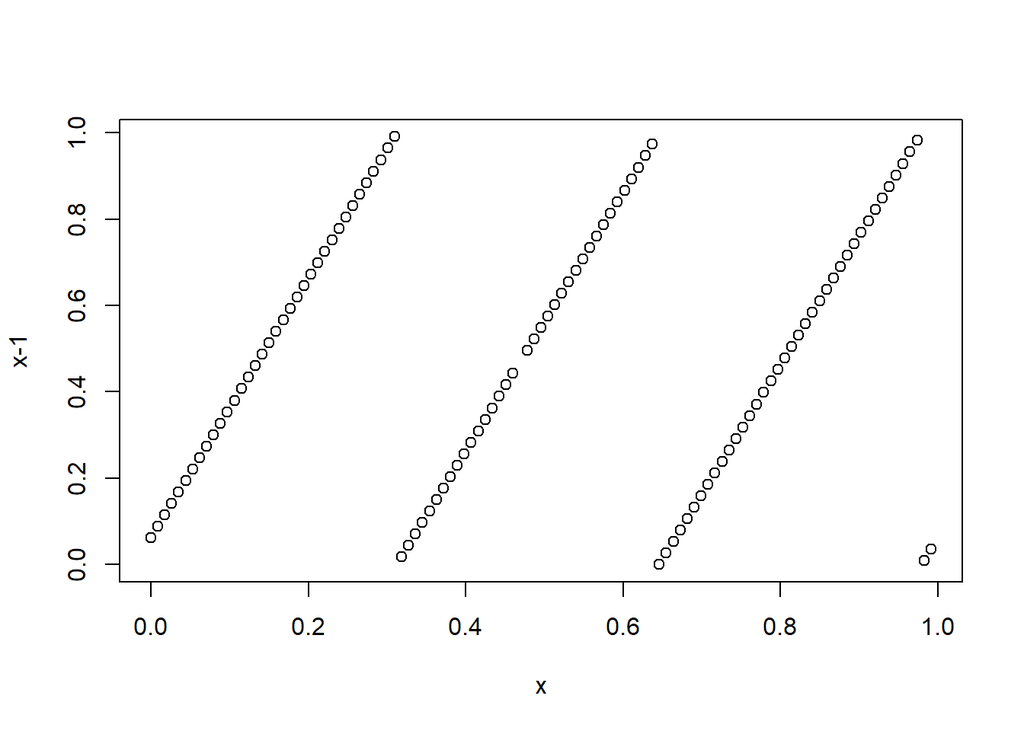

```r
lcg.res <- lcg(5, 3, 7, 113, 226)

plot(x = lcg.res$y[1:225], y = lcg.res$y[-1], xlab = "x", ylab = "x-1")
```

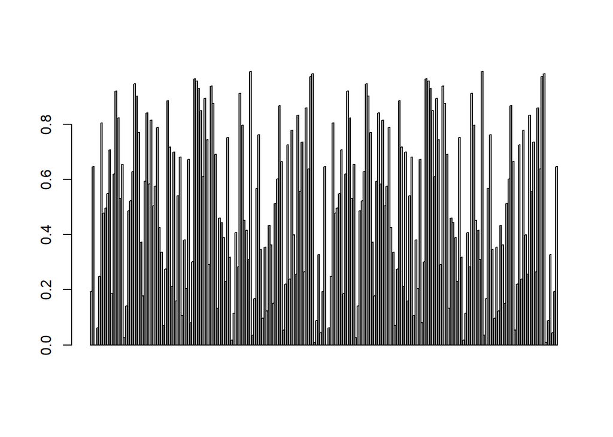

```r
barplot(lcg.res$y)
```

```r
ks.test(lcg.res$y, 'punif')$p.value
```

```
## [1] 1
```

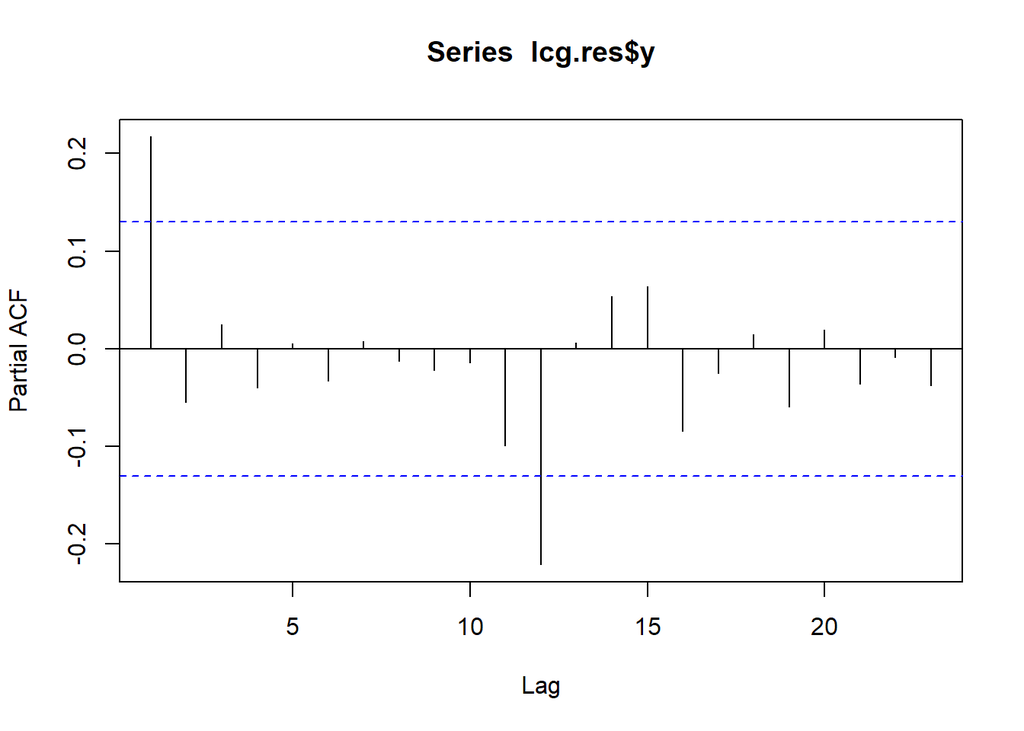

```r
pacf(lcg.res$y)
```

# NÚMEROS PSEUDO-ALEATORIOS Y QUASI-ALEATORIOS

Los únicos cosas que son realmente aleatorias, son las mediciones de fenómenos físicos. La única forma de simular aleatoriedad en los computadores es a través de algoritmos determinísticos. Existen dos formas para generar aleatoriedad: pseudo y quasi.

## Números pseudo-aleatorios

Los métodos pseudo-aleatorios buscan simular *aleatoriedad*

### Linear congruential generators

$$x_n = (ax_{n-1}+c) \quad mod \quad m$$

### Multiple recursive generators

$$x_n = (a_{1}x_{n-1}+\ldots+a_{k}x_{n-k}c) \quad mod \quad m$$

`runif (RNG)`

### Mersenne-Twister

`runif`

### Well equidistributed long-period linear generators

### SIMD-oriented Fast Mersenne Twister algorithms

## Números quasi-aleatorios

Los métodos quasi-aleatorios son determinísticos pero buscan estar equidistribuidos

Monte Carlo para integrar, no buscan la aleatoriedad sino una buena quidistribución, son secuencias de números.

# USAR NÚMEROS ALEATORIOS PARA EVALUAR INTEGRALES

Sea $g(x)$ una función y queremos encontrar $\theta$ tal que:

$$\theta = \int_0^1g(x)dx$$

Si *U* es uniformemente distribuído sobre el mismo soporte que $g(x)$, entonces podemos expresar $\theta$ como $E[g(U)]$

## Para resolver integrales entre $a$ y $b$

Si $\theta = \int_a^bg(x)dx$ con $a < b$, hacemos la siguiente sustitución:

$$y = \frac{x-a}{b-a}$$
$$dy = \frac{dx}{b-a}$$

La nueva integral es:

$$\theta = \int_a^bg(x)dx=\int_0^1g((b-a)y+a)(b-a)d(y)=\int_0^1h(y)dy$$

donde $h(y) = g((b-a)y+a)(b-a)$

- Evaluar la integral $\int_0^{2\pi}\sin(x)dx$ usando simulación Monte Carlo

$$\begin{aligned}
\theta &= \int_{0}^{2\pi}\sin(x)dx \\
&= -\cos(x)\Big|_0^{2\pi} \\
&= \cos(0)-\cos(2\pi) \\
&= 1 - 1 \\
&= 0
\end{aligned}$$

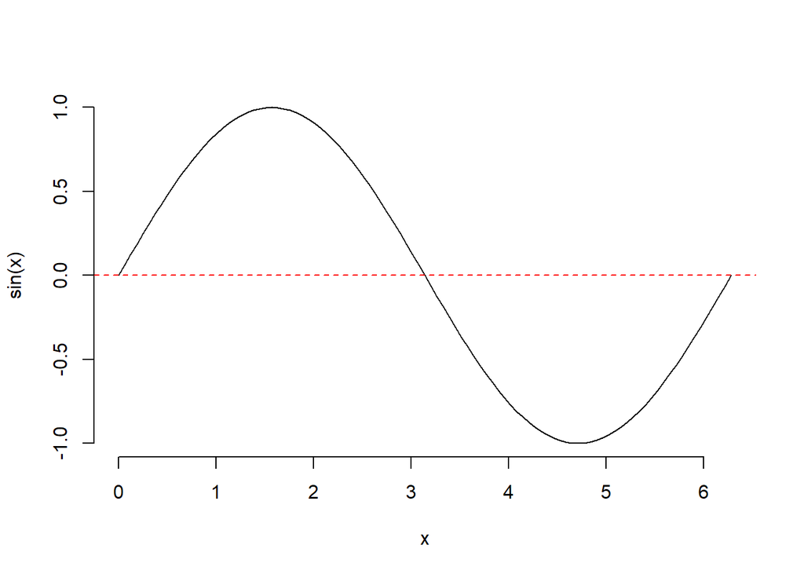

```r
curve(sin(x), 0, 2*pi, frame = FALSE)
abline(h = 0, col = "red", lty = 2)
```

```r
a <- 0
b <- 2*pi
n <- 10000000
g <- function(x) sin(x)
h <- function(y) g(a + (b - a)*y)*(b - a)
u <- runif(n)
mean(h(u))
```

```
## [1] 0.000543054
```

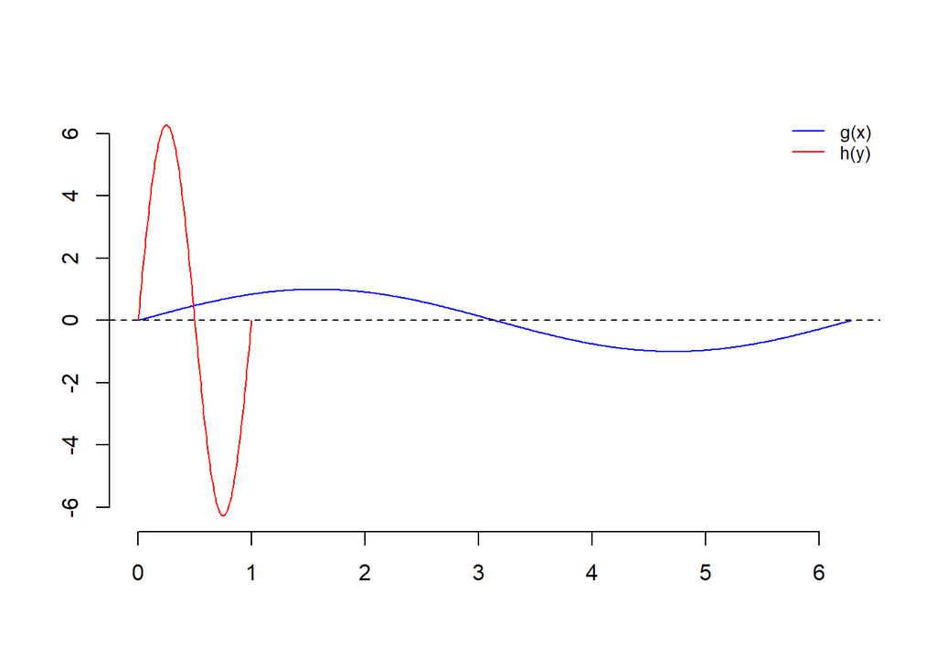

```r
vab <- seq(a, b, 0.01)
v01 <- seq(0, 1, 0.01)

plot(x = vab, y = g(vab), type = "l", col = "blue", xlab = "", ylab = "",
     ylim = c(-2*pi, 2*pi), frame = FALSE)
lines(x = v01, y = h(v01), type = "l", col = "red")
abline(h = 0, col = "black", lty = 2)
legend("topright", legend = c("g(x)", "h(y)"), lty = c(1, 1),
       col = c("blue", "red"), bg = "transparent", bty = "n", cex = 0.8)
```

Evaluar la integral $\int_{\pi}^{3\pi}\cos(x)dx$ usando simulación Monte Carlo

$$\begin{aligned}
\theta &= \int_{\pi}^{3\pi}\cos(x)dx \\
&= \sin(x)\Big|_{\pi}^{3\pi} \\
&= \sin(3\pi)-\sin(\pi) \\
&= 0 - 0 \\
&= 0
\end{aligned}$$

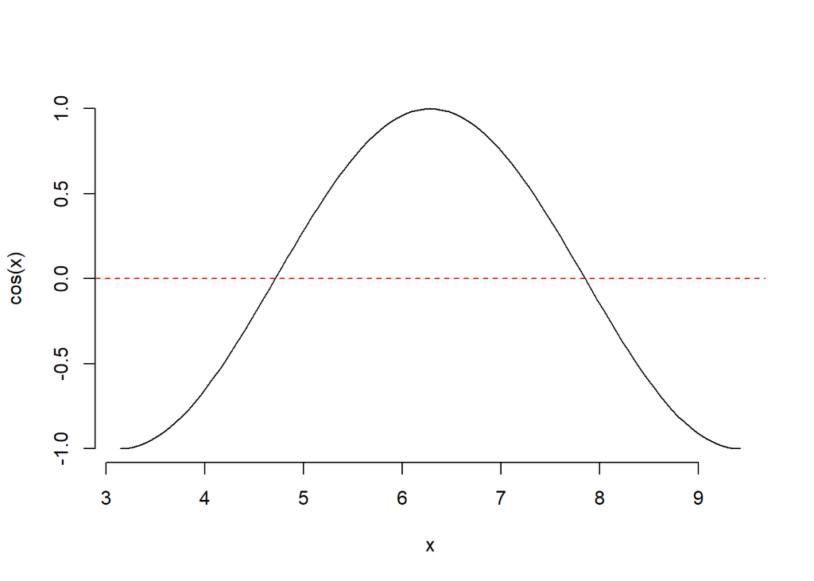

```r
curve(cos(x), pi, 3*pi, frame = FALSE)
abline(h = 0, col = "red", lty = 2)
```

```r
a <- pi
b <- 3*pi
n <- 1000000
g <- function(x) cos(x)
h <- function(y) g(a + (b - a)*y)*(b - a)
u <- runif(n)
mean(h(u))
```

```
## [1] 0.003061404
```

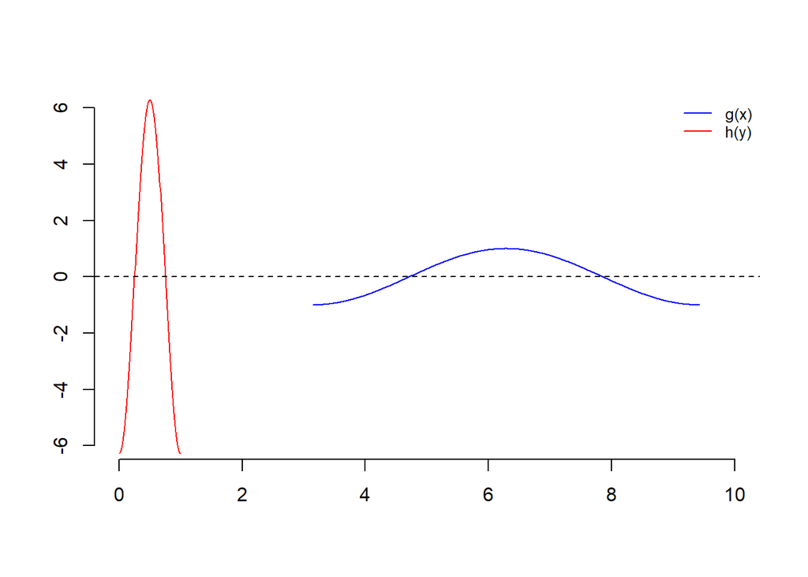

```r
vab <- seq(a, b, 0.01)
v01 <- seq(0, 1, 0.01)

plot(x = vab, y = g(vab), type = "l", col = "blue", xlab = "", ylab = "",
     ylim = c(-6, 6), xlim = c(0, 10), frame = FALSE)
lines(x = v01, y = h(v01), type = "l", col = "red")
abline(h = 0, col = "black", lty = 2)
legend("topright", legend = c("g(x)", "h(y)"), lty = c(1, 1),
       col = c("blue", "red"), bg = "transparent", bty = "n", cex = 0.8)
```